# Statistical Rethinking Chapter 8 Hard

Denis Kozhokar

10/18/2018

# 8H1. Run the model below and then inspect the posterior distribution and explain what it is accomplishing.

```r
library(rethinking)
```

```r
library(rstan)

mp <- map2stan(
    alist(
        a ~ dnorm(0,1),
        b ~ dcauchy(0,1)
    ),
    data=list(y=1),
    start=list(a=0,b=0),
    iter=1e4, warmup=100 , WAIC=FALSE )
```

[output not shown]

[output cut: 218 more lines]

[output not shown]

[output not shown]

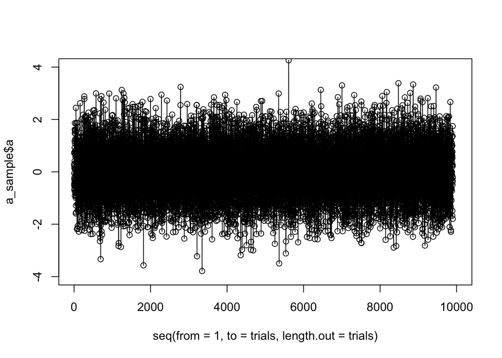

```r
# extract samples for a and b
trials <- 10000
a_sample <- extract.samples(mp, pars="a", n = trials)
b_sample <- extract.samples(mp, pars="b", n = trials)

plot(x = seq(from = 1, to = trials, length.out = trials), y = a_sample$a, ylim = c(-4, 4))
lines(seq(from = 1, to = trials, length.out = trials), a_sample$a)
```

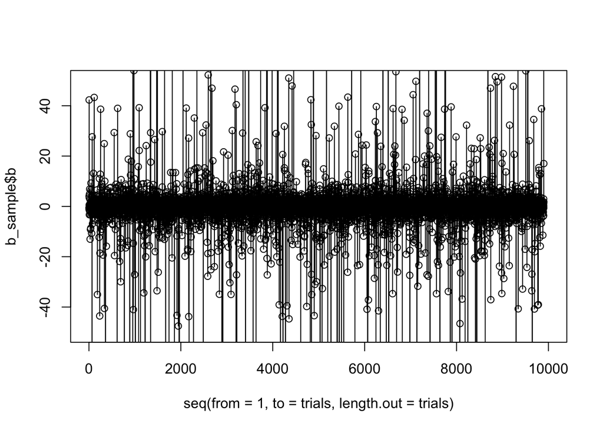

```r
plot(x = seq(from = 1, to = trials, length.out = trials), y = b_sample$b, ylim = c(-50, 50))
lines(seq(from = 1, to = trials, length.out = trials), b_sample$b)
```

# Compare the samples for the parameters a and b. Can you explain the different trace plots, using what you know about the Cauchy distribution?

The book mentions that the couchy distribution has no mean and standard deviations. Because of this, an outlier can overwhelm prior samples. This can be seen in the second plot with a large and unpredictable variance in some samples. But, the central tendancy towards the center point is seen more clearly in the couchy distribution. The Gaussian distribtuion plot is overwhelmingly dense.

# 8H2. Recall the divorce rate example from Chapter 5. Repeat that analysis, using map2stan this time, fitting models m5.1, m5.2, and m5.3. Use compare to compare the models on the basis of WAIC. Explain the results.

```r
data(WaffleDivorce)
d <- WaffleDivorce

# standardize variables
d$Marriage.standardized <- (d$Marriage - mean(d$Marriage)) / sd(d$Marriage)

d$MedianAgeMarriage.standardized <- (d$MedianAgeMarriage - mean(d$MedianAgeMarriage)) / sd(d$MedianAgeMarriage)


m5.1 <- map2stan(
  alist(
    Divorce ~ dnorm( mu , sigma ) ,
    mu <- a + bA * MedianAgeMarriage.standardized ,
    a ~ dnorm( 10 , 10 ) ,
    bA ~ dnorm( 0 , 1 ) ,
    sigma ~ dunif( 0 , 10 )
  ),
  data = d , chains=4 )
```

[output not shown]

[output cut: 298 more lines]

[output not shown]

```
## Computing WAIC
```

```
## Constructing posterior predictions
```

```
## [ 400 / 4000 ]
[ 800 / 4000 ]
[ 1200 / 4000 ]
[ 1600 / 4000 ]
[ 2000 / 4000 ]
[ 2400 / 4000 ]
[ 2800 / 4000 ]
[ 3200 / 4000 ]
[ 3600 / 4000 ]
[ 4000 / 4000 ]
```

```r
m5.2 <- map2stan(
  alist(
    Divorce ~ dnorm( mu , sigma ) ,
    mu <- a + bR * Marriage.standardized ,
    a ~ dnorm( 10 , 10 ) ,
    bR ~ dnorm( 0 , 1 ) ,
    sigma ~ dunif( 0 , 10 )
  ),
  data = d , chains=4 )
```

[output not shown]

[output cut: 298 more lines]

[output not shown]

```
## Computing WAIC
```

```
## Constructing posterior predictions
```

```
## [ 400 / 4000 ]
[ 800 / 4000 ]
[ 1200 / 4000 ]
[ 1600 / 4000 ]
[ 2000 / 4000 ]
[ 2400 / 4000 ]
[ 2800 / 4000 ]
[ 3200 / 4000 ]
[ 3600 / 4000 ]
[ 4000 / 4000 ]
```

```r
m5.3 <- map2stan(
  alist(
    Divorce ~ dnorm( mu , sigma ) ,
    mu <- a + bR*Marriage.standardized + bA*MedianAgeMarriage.standardized ,
    a ~ dnorm( 10 , 10 ) ,
    bR ~ dnorm( 0 , 1 ) ,
    bA ~ dnorm( 0 , 1 ) ,
    sigma ~ dunif( 0 , 10 )
  ),
  data = d , chains=4 )
```

[output not shown]

[output cut: 298 more lines]

[output not shown]

```
## Computing WAIC
```

```
## Constructing posterior predictions
```

```
## [ 400 / 4000 ]
[ 800 / 4000 ]
[ 1200 / 4000 ]
[ 1600 / 4000 ]
[ 2000 / 4000 ]
[ 2400 / 4000 ]
[ 2800 / 4000 ]
[ 3200 / 4000 ]
[ 3600 / 4000 ]
[ 4000 / 4000 ]
```

```r
compare(m5.1,m5.2,m5.3)
```

```
##       WAIC pWAIC dWAIC weight    SE  dSE
## m5.1 186.2   3.8   0.0   0.72 12.50   NA
## m5.3 188.1   4.9   1.9   0.28 12.48 0.76
## m5.2 199.9   3.2  13.6   0.00  9.63 9.16
```

The results demonstrate that the model with the highest accuracy used the median age of marriage to predict divorce. It is important to remember that a smaller WAIC indicates better estimated out-of-sample deviance.

# 8H3. Sometimes changing a prior for one parameter has unanticipated effects on other parameters. This is because when a parameter is highly correlated with another parameter in the posterior, the prior influences both parameters. Here’s an example to work and think through. Go back to the leg length example in Chapter 5. Here is the code again, which simulates height and leg lengths for 100 imagined individuals:

```r
# number of individuals
N <- 100
# sim total height of each
height <- rnorm(N,10,2)
# leg as proportion of height
leg_prop <- runif(N,0.4,0.5)
# sim left leg as proportion + error
leg_left <- leg_prop*height +
    rnorm( N , 0 , 0.02 )
# sim right leg as proportion + error
leg_right <- leg_prop*height +
    rnorm( N , 0 , 0.02 )
# combine into data frame
dataframe <- data.frame(height,leg_left,leg_right)
```

And below is the model you fit before, resulting in a highly correlated posterior for the two beta parameters. This time, fit the model using map2stan:

```r
m5.8s <- map2stan(
    alist(
        height ~ dnorm( mu , sigma ) ,
        mu <- a + bl*leg_left + br*leg_right ,
        a ~ dnorm( 10 , 100 ) ,
        bl ~ dnorm( 2 , 10 ) ,
        br ~ dnorm( 2 , 10 ) ,
        sigma ~ dcauchy( 0 , 1 )
),
data=dataframe, chains=4, start=list(a=10,bl=0,br=0,sigma=1) )
```

[output not shown]

[output cut: 282 more lines]

[output not shown]

[output not shown]

```
## Computing WAIC
```

```
## Constructing posterior predictions
```

```
## [ 400 / 4000 ]
[ 800 / 4000 ]
[ 1200 / 4000 ]
[ 1600 / 4000 ]
[ 2000 / 4000 ]
[ 2400 / 4000 ]
[ 2800 / 4000 ]
[ 3200 / 4000 ]
[ 3600 / 4000 ]
[ 4000 / 4000 ]
```

Compare the posterior distribution produced by the code above to the posterior distribution produced when you change the prior for br so that it is strictly positive:

```r
m5.8s2 <- map2stan(
    alist(
        height ~ dnorm( mu , sigma ) ,
        mu <- a + bl*leg_left + br*leg_right ,
        a ~ dnorm( 10 , 100 ) ,
        bl ~ dnorm( 2 , 10 ) ,
        br ~ dnorm( 2 , 10 ) & T[0,] ,
        sigma ~ dcauchy( 0 , 1 )
),
data=dataframe, chains=4, start=list(a=10,bl=0,br=0,sigma=1) )
```

[output not shown]

[output cut: 282 more lines]

[output not shown]

[output not shown]

```
## Computing WAIC
```

```
## Constructing posterior predictions
```

```
## [ 400 / 4000 ]
[ 800 / 4000 ]
[ 1200 / 4000 ]
[ 1600 / 4000 ]
[ 2000 / 4000 ]
[ 2400 / 4000 ]
[ 2800 / 4000 ]
[ 3200 / 4000 ]
[ 3600 / 4000 ]
[ 4000 / 4000 ]
```

Note that T[0,] on the right-hand side of the prior for br. What the T[0,] does is truncate the normal distribution so that it has positive probability only above zero. In other words, that prior ensures that the posterior distribution for br will have no probability mass below zero. Compare the two posterior distributions for m5.8s and m5.8s2. What has changed in the posterior distribution of both beta parameters? Can you explain the change induced by the change in prior?

```r
precis(m5.8s)
```

```
##       Mean StdDev lower 0.89 upper 0.89 n_eff Rhat
## a     1.19   0.30       0.73       1.65  2060    1
## bl    0.83   1.96      -2.31       3.85  1207    1
## br    1.11   1.96      -1.90       4.25  1203    1
## sigma 0.59   0.04       0.53       0.66  2063    1
```

```r
precis(m5.8s2)
```

```
##        Mean StdDev lower 0.89 upper 0.89 n_eff Rhat
## a      1.21   0.29       0.73       1.68  1452    1
## bl    -0.05   1.40      -1.84       1.98   440    1
## br     1.98   1.40       0.00       3.78   440    1
## sigma  0.59   0.04       0.52       0.66  1177    1
```

# 8H4. For the two models fit in the previous problem, use DIC or WAIC to compare the effective numbers of parameters for each model. Which model has more effective parameters? Why?

```r
compare(m5.8s, m5.8s2)
```

```
##         WAIC pWAIC dWAIC weight   SE  dSE
## m5.8s2 179.5   2.4   0.0   0.63 9.76   NA
## m5.8s  180.6   3.1   1.1   0.37 9.60 0.87
```

# 8H5. Modify the Metropolis algorithm code from the chapter to handle the case that the island populations have a different distribution than the island labels. This means the island’s number will not be the same as its population.

```r
#I know this is wrong.

MetropolisIslands=function(num_weeks = 1e5,start=1)
{
positions <- rep(0,num_weeks)
current <- start
for ( i in 1:num_weeks ) {
  # flip coin to generate proposal
  proposal <- current + sample( c(-1,1) , size=1 )
  # now make sure he loops around the archipelago
  if ( proposal < 1 )  proposal <- 10
  if ( proposal > 10 ) proposal <- 1
  # move?
  prob_move <- proposal/current
  current <- ifelse( runif(1) < prob_move , proposal , current )
  # record current position
  positions[i] <- current
}
return(positions)
}
positionsnow <- MetropolisIslands(num_weeks=100,start=3)
positionsnow
```

```
##   [1]  2  1  2  3  4  3  2  3  3  4  4  3  4  4  3  4  5  6  7  8  9  8  9
##  [24]  9  8  9  8  9 10 10  9 10  9 10 10 10 10  9  8  7  6  7  8  7  8  9
##  [47]  8  9 10 10 10  9  8  7  8  7  6  5  6  7  8  7  6  5  6  6  7  6  7
##  [70]  8  9 10  9 10  9 10  9 10  1  2  3  2  3  2  3  2  3  3  4  4  5  5
##  [93]  6  7  8  8  9  8  9  8
```

# 8H6. Modify the Metropolis algorithm code from the chapter to write your own simple MCMC estimator for globe tossing data and model from Chapter 2.

```r
#I know this is wrong as well

Globetoss=function(length = 1000,start=1)
{
positions <- rep(0,1)
current <- start
for ( i in 1:length ) {
  # flip coin to generate proposal
  proposal <- current + sample( c(-1,1) , size=1 )
  # now make sure he loops around the archipelago
  if ( proposal < 6 )  proposal <- 9
  if ( proposal > 9 ) proposal <- 6
  # move?
  prob_move <- proposal/current
  current <- ifelse( runif(1) < prob_move , proposal , current )
  # record current position
  positions[i] <- current
}
return(positions)
}
Globetossnow <- Globetoss(length=1000,start=1)
Globetossnow
```

```
##    [1] 9 8 9 8 7 8 9 6 9 9 9 6 9 6 9 8 7 8 9 8 9 8 9 8 7 8 9 6 9 6 9 6 7 8
##   [35] 9 8 7 6 9 8 9 6 7 8 7 7 7 8 7 6 9 6 9 9 9 8 9 6 7 6 9 9 6 9 6 9 6 9
##   [69] 8 9 6 7 8 7 8 7 6 9 9 6 9 8 9 9 6 9 8 7 7 8 7 6 7 8 9 6 7 8 9 9 8 7
##  [103] 8 9 6 7 6 9 8 7 6 9 8 9 8 7 8 7 8 7 6 7 8 9 8 9 6 9 8 7 8 9 6 7 8 7
##  [137] 7 8 9 6 9 8 9 8 8 8 7 6 7 7 6 9 6 7 8 9 6 7 8 9 8 8 7 8 7 8 9 6 9 8
##  [171] 9 8 9 9 8 9 6 9 9 8 7 8 9 8 7 8 9 6 9 8 7 8 9 6 7 6 9 8 7 7 8 7 6 7
##  [205] 6 9 8 7 8 8 9 6 7 8 7 8 9 8 7 8 7 7 7 6 9 8 9 8 9 6 9 8 7 8 7 8 9 9
##  [239] 8 9 8 9 6 7 8 7 8 9 8 9 6 9 8 9 8 7 6 9 6 7 8 7 8 9 8 9 6 9 8 7 8 9
##  [273] 9 8 9 8 9 8 9 6 7 6 7 8 7 8 9 8 7 6 7 8 8 7 8 7 8 9 6 7 6 9 9 8 9 9
##  [307] 8 7 6 9 6 7 6 9 9 8 9 9 6 9 6 7 8 9 8 9 9 6 9 8 9 8 9 8 9 9 8 7 6 9
##  [341] 8 9 9 8 9 8 9 9 8 9 6 9 6 9 8 7 8 7 8 9 9 6 7 6 9 8 9 6 9 6 9 9 8 9
##  [375] 6 9 6 9 6 9 8 7 6 7 8 7 8 9 8 7 6 9 8 9 8 9 6 7 8 7 6 9 8 9 9 9 8 9
##  [409] 6 7 8 7 6 7 8 7 6 7 6 7 8 9 6 9 6 7 6 9 8 7 8 9 8 7 8 9 6 9 6 9 6 7
##  [443] 6 9 8 9 8 9 6 7 6 7 6 7 8 7 8 9 6 9 8 7 8 7 6 7 6 7 6 7 8 8 9 8 7 8
##  [477] 7 6 9 8 7 7 6 7 8 9 6 9 8 9 9 6 9 8 9 8 7 6 9 8 7 7 8 9 6 9 9 8 7 8
##  [511] 8 9 6 9 8 9 8 7 7 8 7 6 9 8 9 8 7 6 7 7 8 7 6 9 8 9 8 8 9 9 6 9 8 8
##  [545] 9 8 7 6 7 6 9 8 9 9 8 9 8 9 9 6 9 6 9 6 9 6 7 6 7 6 7 6 7 8 9 8 9 9
##  [579] 9 6 9 9 9 9 6 7 8 7 6 7 8 9 6 7 8 9 9 9 9 8 7 8 9 8 7 8 7 8 7 8 9 8
##  [613] 8 9 8 7 8 9 8 7 6 9 8 9 8 9 8 9 8 9 6 7 8 9 6 7 8 9 8 9 8 9 9 8 9 6
##  [647] 7 6 7 6 7 6 9 6 9 8 9 8 9 6 7 6 7 8 9 9 9 8 9 8 7 8 8 9 8 9 9 9 8 9
##  [681] 9 9 9 9 6 7 6 7 8 7 6 7 8 7 6 7 8 7 6 7 8 9 9 9 8 7 7 6 9 8 7 6 7 7
##  [715] 6 9 8 9 6 9 6 9 6 9 8 9 8 9 8 9 9 8 9 9 9 9 8 9 6 7 6 9 9 8 9 9 8 7
##  [749] 8 9 6 7 6 7 6 7 6 7 8 9 6 7 8 7 8 9 8 9 8 9 8 7 8 7 6 7 6 9 8 9 6 9
##  [783] 8 8 9 9 6 9 8 7 6 9 8 7 7 6 7 6 9 9 9 8 7 8 9 6 9 8 7 8 9 8 9 9 8 9
##  [817] 9 8 9 6 7 8 7 6 9 6 7 6 7 8 7 6 7 8 9 9 9 9 8 7 8 9 8 7 6 9 8 7 8 7
##  [851] 8 7 8 7 8 9 6 7 8 9 8 7 6 9 8 9 6 9 8 9 8 9 8 9 6 7 8 9 8 9 8 9 8 9
##  [885] 8 9 8 8 9 6 7 6 7 8 9 6 7 6 9 9 8 9 6 9 6 9 6 7 8 7 8 7 8 7 8 9 8 9
##  [919] 8 9 8 9 8 9 8 7 8 7 7 8 8 9 6 9 8 7 6 7 7 8 9 8 9 9 6 9 8 9 9 9 6 7
##  [953] 7 6 7 6 9 8 7 6 9 6 7 6 7 6 9 9 8 7 8 7 8 9 9 6 7 8 7 8 9 6 7 6 9 8
##  [987] 7 6 7 6 9 9 6 9 8 7 7 7 6 7
```